# Assignment 3: Cleaning, summarizing, and more graphing

Shimeng Dai

This assignment involves two different datasets. For simplicity (and to ensure consistency across computer operating systems), I have saved all of the relevant data in an .RData file, which is loaded as follows:

```r
library(tidyverse)

setwd("~/Desktop/University of Texas/The fifth semester/Data analysis in R/HW3")
load("Assignment 3 data.RData")
ls()
```

```
## [1] "adulthood_dat"     "BianLeslieCimpian"
```

# 1 Gender stereotypes

A recent study by [Bian, Leslie, and Cimpian (2017)](http://science.sciencemag.org/content/355/6323/389.full) examined the development of gender stereotypes about intellectual ability among children between the ages of five and seven. The data from this article are available on the Open Science Framework [here](https://osf.io/yund6/?view_only=9a8505d4e87b456a89f255b43e21234e). I have downloaded the data from Studies 1 and 2 and read it into R. The results are stored in this data frame:

```r
glimpse(BianLeslieCimpian)
```

```
## Rows: 480
## Columns: 11
## $ study  <dbl> 1, 1, 1, 1, 1, 1, 1, 1, 1, 1, 1, 1, 1, 1, 1, 1, 1, 1, 1, 1, 1,…
## $ subj   <dbl> 1, 2, 3, 4, 5, 6, 7, 8, 9, 10, 11, 12, 13, 14, 15, 16, 17, 18,…
## $ gender <dbl> 2, 2, 2, 1, 1, 1, 2, 2, 2, 1, 2, 2, 1, 1, 2, 2, 2, 1, 2, 1, 2,…
## $ age    <dbl> 7, 7, 7, 6, 7, 5, 5, 5, 5, 5, 6, 7, 6, 6, 5, 5, 6, 6, 6, 6, 6,…
## $ trait  <dbl> 1, 1, 1, 1, 1, 1, 1, 1, 1, 1, 1, 1, 1, 1, 1, 1, 1, 1, 1, 1, 1,…
## $ stereo <dbl> 0.6111111, 0.2777778, 0.7222222, 0.5555556, 1.0000000, 1.00000…
## $ race   <dbl> 6, NA, NA, NA, NA, 6, 5, 5, 2, 5, 2, 5, 2, NA, 5, NA, NA, NA, …
## $ race2  <dbl> 0, NA, NA, NA, NA, 0, 1, 1, 0, 1, 0, 1, 0, NA, 1, NA, NA, NA, …
## $ eduave <dbl> 20, NA, NA, NA, NA, 20, 16, 16, 16, 20, 17, 19, 18, NA, 13, NA…
## $ income <dbl> 55000, NA, NA, NA, NA, 55000, 110000, 90000, 55000, 175000, 16…
## $ ses    <dbl> 0.18709696, NA, NA, NA, NA, 0.18709696, -0.20352885, -0.406612…
```

The codebook for this dataset can be viewed [here](https://osf.io/jfm26/?view_only=9a8505d4e87b456a89f255b43e21234e) (I’ve also posted it on Canvas).

## 1.1 Aesthetic mapping (2 pt)

Read the abstract of the article and take a look at [Figure 1](https://d2ufo47lrtsv5s.cloudfront.net/content/sci/355/6323/389/F1.large.jpg). What variables are encoded in Figure 1? Write out the full aesthetic mapping of the figure. Don’t forget to include variables mapped to horizontal and vertical facets.

- **Age** is mapped to horizontal position
- **Brilliance score** is mapped to vertical position
- **Niceness score** is mapped to **vertical position**
- **Study** is mapped onto column facets - horizontal.
- **Trait (brilliance and niceness)** is mapped to **row facets - vertical**
- **Gender is mapped onto the color of the line and point**

## 1.2 Means and SEs (2 pts)

Figure 1 includes three distinct geometric representations:

1. `geom_point` corresponding to the average stereotype score for each age group and gender.
2. `geom_line` is used to connect the points across age groups.
3. `geom_errorbar` corresponds to a range of +/- 1 standard error (SE) from the mean stereotype score for each age group and gender.

The next question asks you to create a plot similar to Figure 1. In order to do so, you will first need to calculate summary statistics for each of of several subgroups of observations. Calculate the mean, standard deviation, and sample size for each distinct subgroup represented in Figure 1. Then calculate the standard error for each subgroup using the formula:
$$SE = \frac{SD}{\sqrt{n}}$$
where $SD$ is the sample standard deviation and $n$ is the number of observations used to compute the mean and SD for a given subgroup. Finally, calculate the minimum and maximum values of the error bars by taking the mean and subtracting/adding the SE.

```r
summary_dat <- BianLeslieCimpian %>%  # change this to your cleaned up data
 group_by(study, trait, gender, age) %>%
  summarise(
    M = mean(stereo),
    SD = sd(stereo),
    n = n()
  ) %>%
  mutate(
    SE = SD / sqrt(n),
    y_min = M - SE,
    y_max = M + SE
  ) %>% mutate(gender = recode(gender, "1" = "male", "2"= "female")) %>% mutate(trait = recode(trait, "0" = "nice", "1"= "smart"))
```

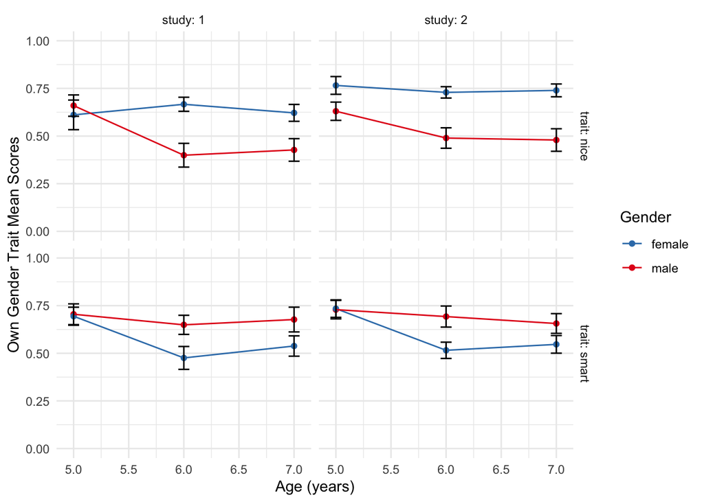

```r
summary_dat %>%
ggplot(aes(x = age, y = M)) +
geom_point(aes(color = gender)) +
  geom_line(aes(color = gender)) +
  geom_errorbar(aes(ymin = y_min, ymax = y_max), width = 0.1) +
  facet_grid(trait ~ study, labeller = "label_both") + # use face grid to split by trait and study
  scale_color_brewer(type = "qual", palette = 6, direction = -1) +
  labs(x = "Age (years)", y = "Own Gender Trait Mean Scores", color = "Gender") +
  ylim(0, 1) + # add limits
  theme_minimal()
```

## 1.3 Summary statistics for five year olds (1 pt)

Use `kable` to show some of the results from the previous question. Specifically, make a table that reports the mean, SE, and error bar range *for the subgroups of five year olds only*. *Hint: the table should have 8 rows.*

```r
library(knitr)
summary_dat %>% filter(age ==5) %>% select( M, SE, y_min, y_max)  %>% kable(digits = 3)
```

| study | trait | gender | M | SE | y_min | y_max |
| --- | --- | --- | --- | --- | --- | --- |
| 1 | nice | male | 0.660 | 0.056 | 0.604 | 0.716 |
| 1 | nice | female | 0.611 | 0.078 | 0.533 | 0.689 |
| 1 | smart | male | 0.705 | 0.055 | 0.650 | 0.759 |
| 1 | smart | female | 0.694 | 0.047 | 0.647 | 0.742 |
| 2 | nice | male | 0.630 | 0.048 | 0.582 | 0.678 |
| 2 | nice | female | 0.766 | 0.047 | 0.719 | 0.812 |
| 2 | smart | male | 0.729 | 0.049 | 0.681 | 0.778 |
| 2 | smart | female | 0.734 | 0.046 | 0.688 | 0.780 |

## 1.4 Recreate Figure 1 (2 pts)

Using `ggplot2`, create a graph that has the same structure as Figure 1.

Note: the style/appearance of your recreation does NOT need to exactly replicate the style of Figure 1 from the article. For instance, it would be fine to use different colors instead of red and blue, and you do NOT need to include the sub-figure labels **A**, **B**, **C**, and **D**. However, you should ensure that your version of the figure does have meaningful labels and does follow the general principles of good statistical graphics that we have discussed in class.

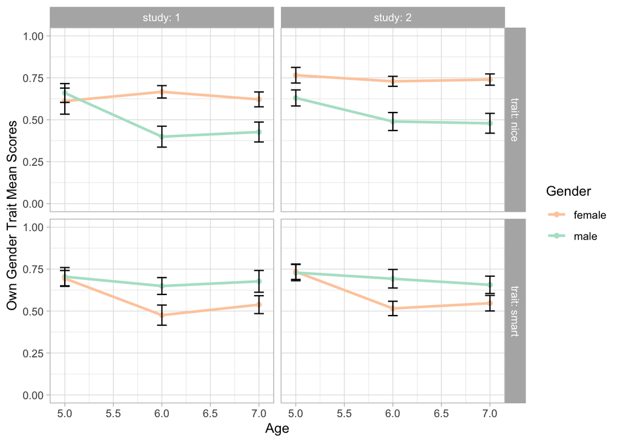

```r
summary_dat %>%
ggplot(aes(x = age, y = M)) +
geom_point(aes(color = gender)) +
  geom_line(aes(color = gender), size = 1) +
  geom_errorbar(aes(ymin = y_min, ymax = y_max), width = 0.1) +
  facet_grid(trait ~ study, labeller = "label_both") +
  scale_color_brewer(type = "qual", palette = 5, direction = -1) +
  labs(x = "Age", y = "Own Gender Trait Mean Scores", color = "Gender") +
  ylim(0, 1) +
  theme_light()
```

## 1.5 Extra credit: Improve on Figure 1 (2 pts)

A potential critique of Figure 1 is that it shows only summary statistics (means and standard errors), rather than the raw data. It is therefore difficult to get a sense of the distribution of the gender stereotype measure. Create a new version of Figure 1 that represents the full distribution of the stereotype measure for each age group and gender, *while still depicting the mean or median of each subgroup of observations*.

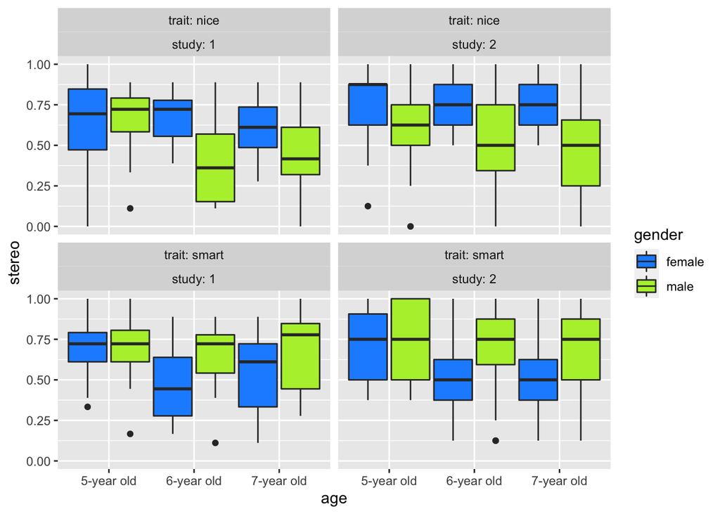

```r
Extra_credit <-BianLeslieCimpian %>%
  mutate(
    trait = recode(trait, "0" = "nice", "1"= "smart"),
    gender = recode(gender, "1" = "male", "2"= "female"),
    age = recode(age, "5" = "5-year old", "6" = "6-year old","7" = "7-year old")
    )


ggplot(Extra_credit, aes(x= age, y = stereo, fill= gender)) +
 facet_wrap(trait ~ study,labeller = "label_both")+
  geom_boxplot(  position = "dodge2", width = 1)+
  scale_fill_manual(values=c("dodgerblue1", "olivedrab2"))
```

# 2 Emerging adulthood

In these exercises, you will work with data from the study of emerging adulthood that we looked at briefly in assignment 1. The goal of the study was to investigate correlations between measures of emerging adulthood and a range of other psychological constructs, including subjective well-being, mindfulness, belonging, self-efficacy, somatic health, and perceived stress, among others. Data were collected by collaborators from 32 different academic institutions. You can view the survey instrument here: https://osf.io/t3w2p/

I have downloaded the data and taken a subset of the variables from the full dataset. The results are stored in an object called `adulthood_dat`:

```r
glimpse(adulthood_dat)
```

```
## Rows: 4,341
## Columns: 48
## $ StartDate   <dttm> 2016-10-05 17:53:53, 2016-10-06 08:01:53, 2016-10-06 08:…
## $ EndDate     <dttm> 2016-10-05 18:28:07, 2016-10-06 08:31:43, 2016-10-06 08:…
## $ affiliation <chr> "stockton", "swansea", "swansea", "swansea", "swansea", "…
## $ age         <dbl> 18, 18, 18, 18, 18, 18, 18, 18, 18, 18, 18, 18, 18, 18, 1…
## $ race        <chr> "1", "1", "1", "1", "1", "4", "1", "1", "2", "1", "1", "1…
## $ efficacy_1  <dbl> 3, 2, 3, 3, 3, 3, 3, 4, 3, 4, 4, 4, 4, 3, 3, 3, 3, 3, 4, …
## $ efficacy_2  <dbl> 3, 2, 2, 3, 3, 2, 3, 3, 3, 3, 4, 3, 3, 3, 3, 3, 2, 3, 4, …
## $ efficacy_3  <dbl> 4, 3, 2, 3, 3, 3, 4, 3, 3, 3, 4, 4, 4, 3, 3, 3, 3, 3, 4, …
## $ efficacy_4  <dbl> 3, 3, 3, 3, 4, 2, 4, 4, 3, 3, 3, 3, 3, 3, 3, 3, 3, 3, 4, …
## $ efficacy_5  <dbl> 3, 3, 3, 4, 3, 3, 3, 4, 3, 3, 4, 3, 3, 3, 3, 3, 2, 3, 3, …
## $ efficacy_6  <dbl> 3, 2, 3, 4, 2, 3, 4, 4, 3, 4, 3, 4, 3, 4, 4, 3, 3, 3, 4, …
## $ efficacy_7  <dbl> 3, 3, 2, 4, 2, 3, 4, 4, 3, 2, 3, 3, 2, 2, 4, 3, 3, 3, 4, …
## $ efficacy_8  <dbl> 2, 3, 2, 3, 3, 3, 3, 3, 3, 4, 4, 3, 3, 3, 3, 3, 3, 3, 4, …
```

[output cut: 35 more lines]

## 2.1 Data cleaning (3 pts)

Create a clean version of the dataset, stored in an object called `adulthood_clean`, after doing the following:

1. Exclude respondents who completed less than 80% of the survey (the variable `progress` reports the percentage of the survey instrument completed).
2. Exclude respondents who failed the attention check (`attention == 7` corresponds to passing the attention check; missing values or values less than 7 correspond to failing the attention check).
3. Exclude respondents who completed the survey in less than 10 minutes (the `duration` variable reports completion time *in seconds*).
4. Create a composite self-efficacy measure (call it `self_efficacy`) equal to the sum of `efficacy_1` through `efficacy_10`.
5. Create a composite sense of belonging measure (call it `belonging`) equal to the sum of `belong_1` through `belong_10`.
6. Create a composite measure of adult achievements (call it `adulthood`) equal to the sum of `moa1#2_1` through `moa1#2_10` and `moa2#2_1` through `moa2#2_10`.

```r
adulthood_clean <- adulthood_dat%>% filter (progress >= 80, attention == 7, duration >= 600) %>% mutate(
    self_efficacy = rowSums(select(., starts_with("efficacy"))),
    belonging = rowSums(select(., starts_with("belong"))),
    adulthood = rowSums(select(., starts_with("moa")))
  )

head(adulthood_clean)
```

```
## # A tibble: 6 x 51
##   StartDate           EndDate             affiliation   age race  efficacy_1
##   <dttm>              <dttm>              <chr>       <dbl> <chr>      <dbl>
## 1 2016-10-05 17:53:53 2016-10-05 18:28:07 stockton       18 1              3
## 2 2016-10-06 08:01:53 2016-10-06 08:31:43 swansea        18 1              2
## 3 2016-10-06 08:01:54 2016-10-06 08:35:57 swansea        18 1              3
## 4 2016-10-06 08:07:27 2016-10-06 08:33:41 swansea        18 1              3
## 5 2016-10-07 02:09:45 2016-10-07 02:29:49 swansea        18 1              3
## 6 2016-10-07 05:57:04 2016-10-07 06:22:14 michiganst…    18 4              3
## # … with 45 more variables: efficacy_2 <dbl>, efficacy_3 <dbl>,
## #   efficacy_4 <dbl>, efficacy_5 <dbl>, efficacy_6 <dbl>, efficacy_7 <dbl>,
## #   efficacy_8 <dbl>, efficacy_9 <dbl>, efficacy_10 <dbl>, belong_1 <dbl>,
## #   belong_2 <dbl>, belong_3 <dbl>, belong_4 <dbl>, belong_5 <dbl>,
## #   belong_6 <dbl>, belong_7 <dbl>, belong_8 <dbl>, belong_9 <dbl>,
## #   belong_10 <dbl>, `moa1#2_1` <dbl>, `moa1#2_2` <dbl>, `moa1#2_3` <dbl>,
## #   `moa1#2_4` <dbl>, `moa1#2_5` <dbl>, `moa1#2_6` <dbl>, `moa1#2_7` <dbl>,
## #   `moa1#2_8` <dbl>, `moa1#2_9` <dbl>, `moa1#2_10` <dbl>, `moa2#2_1` <dbl>,
## #   `moa2#2_2` <dbl>, `moa2#2_3` <dbl>, `moa2#2_4` <dbl>, `moa2#2_5` <dbl>,
## #   `moa2#2_6` <dbl>, `moa2#2_7` <dbl>, `moa2#2_8` <dbl>, `moa2#2_9` <dbl>,
## #   `moa2#2_10` <dbl>, progress <dbl>, duration <dbl>, attention <dbl>,
## #   self_efficacy <dbl>, belonging <dbl>, adulthood <dbl>
```

## 2.2 Missingness (1 pt)

What proportion of observations in the cleaned dataset (i.e., after excluding observations per the previous question) are missing values on the composite measures of self-efficacy, sense of belonging, and adult achievements, respectively? For each of these measures, calculate the proportion of observations that are missing.

```r
mean(is.na(adulthood_clean$self_efficacy))
```

```
## [1] 0.0009557184
```

```r
mean(is.na(adulthood_clean$belonging))
```

```
## [1] 0.001274291
```

```r
mean(is.na(adulthood_clean$adulthood))
```

```
## [1] 0.08728895
```

## 2.3 Largest sample sizes by school (2 pts)

Calculate the number of participants by school (using the `affiliation` variable) and look carefully at the labels. Note that there are some typos in the affiliations from `"snevada"`. Fix these typos and then recalculate the sample size by school. Make a table listing the names and sample sizes for the schools contributing sample sizes of 90 or more participants.

```r
adulthood_new <- adulthood_clean %>%
 mutate(affiliation = recode(affiliation, "snevada Previous Next" = "snevada", "snevada  Previous Next" = "snevada")
  )


adulthood_table <-  adulthood_new %>% group_by(`affiliation`)  %>% summarize(n_schools = n(), .groups = "drop") %>% filter(n_schools >= 90)


 kable(adulthood_table)
```

| affiliation | n_schools |
| --- | --- |
| adamsstate | 140 |
| bradley | 101 |
| juniata | 191 |
| mercer | 90 |
| michiganstate | 191 |
| Norco | 98 |
| paradise | 138 |
| plu | 113 |
| riversidecc | 112 |
| samaug | 128 |
| snevada | 96 |
| stockton | 142 |
| SUNYfredonia | 168 |
| swansea | 181 |
| willamette | 131 |

## 2.4 Within-school correlations (2 pts)

For the set of schools with sample sizes of 90 or more, calculate the correlation between self-efficacy and adult achievement *separately for each school*. What are the largest and smallest within-school correlations, and from what schools were these correlations calculated?

```r
data.cor <- adulthood_new %>% filter(affiliation %in% c("adamsstate","bradley","juniata","mercer",      "michiganstate","Norco","paradise","plu","riversidecc","samaug","snevada","stockton",      "SUNYfredonia","swansea","willamette"))

correlate <- data.cor %>% group_by(`affiliation`) %>% summarise(r = cor(`self_efficacy`, `adulthood`,use = "complete.obs"))
correlate %>% arrange(abs(r))
```

```
## # A tibble: 15 x 2
##    affiliation        r
##    <chr>          <dbl>
##  1 samaug        0.0854
##  2 swansea       0.195
##  3 SUNYfredonia  0.202
##  4 bradley       0.228
##  5 stockton      0.255
##  6 juniata       0.267
##  7 michiganstate 0.289
##  8 snevada       0.300
##  9 mercer        0.316
## 10 plu           0.326
## 11 adamsstate    0.333
## 12 Norco         0.359
## 13 willamette    0.396
## 14 riversidecc   0.404
## 15 paradise      0.416
```

```r
max(correlate$r)#paradise
```

```
## [1] 0.4162889
```

The school with the largest with-in correlation is paradise.

```r
min(correlate$r)#samaug
```

```
## [1] 0.08541729
```

The school with the smallest with-in correlation is samaug.